# Introducción a Bash

El Colegio de la Frontera Sur, Unidad Villahermosa 2025

## 1. Presentación del Curso

Instructores: Dra. Gabriela Castellanos Morales, Dr. Jaime Gasca, M.C. Anahí Canedo Téxon.  
Duración del curso: 20 horas (6 sesiones de 3 horas cada una), 2 horas de trabajo en casa.  
Horario: Martes, miércoles y viernes 15:00 a 18:00 hrs.  
Fecha de inicio: 4 de febrero 2025 Fecha de término: 14 de febrero 2025

*Objetivo del curso en línea:* Que los y las estudiantes aprendan los comandos básicos de lenguaje BASH y sean capaces de moverse dentro del sistema de archivos de sus computadoras desde una terminal o interfaz de líneas de comandos, así como crear scripts, y ejecutarlos desde línea de comandos.  
*Perfil de ingreso:* Estudiantes de nivel medio y superior con interés en aprender las bases para moverse dentro del sistema de archivos de sus computadoras desde una terminal o interfaz de línea de comandos. No es requisito contar con conocimientos previos de programación.  
*Perfil de egreso:* Los estudiantes serán capaces de moverse dentro del sistema de archivos de sus computadoras desde una terminal o interfaz de líneas de comandos, así como crear, copiar, mover, eliminar y modificar archivos, generar scripts, hacer bucles o loops y ejecutarlos desde línea de comandos.

*Evaluación.*  
10% Quiz  
30% Prácticas  
40% Examen Final  
20% Asistencia

*Requerimientos*  
- Computadora 8 Gb mínimo RAM , 500 Gb memoria, 64 bit  
- Acceso a internet estable, de preferencia mediante cable ethernet - Acceso a terminal de bash:  
- Puedes utilizar Mac, cualquier distribución de Linux (ej. ubuntu 24.0) - Si tu sistema operativo es Windows entonces instala MobaXterm

## 2. Breve introducción sobre Linux

- **Linux o GNU/Linux es un sistema operativo, como un Windows o Mac**.  
  Es multitarea, multiusuario, multiplataforma y multiprocesador. Fué creado originalmente por Linus Torvalds en 1991, en la Universidad de Helsinki, en Finlandia, a diferencia de Windows y otros sistemas operativos propietarios, ha sido desarrollado por miles de usuarios de computadoras de todo el mundo, contribuyendo todos con el fin de conseguir un sistema operativo confiable, robusto, poderoso, seguro e interactivo.
- **Linux es el núcleo dentro del proyecto de GNU**.  
  Según su manifiesto, el objetivo fundacional del proyecto es construir un sistema operativo libre y, si es posible, “todas las utilidades que normalmente acompañan a un sistema Unix para que se pueda prescindir de cualquier software que no sea libre”.
- **Software libre, eso quiere decir que además de ser gratuito también podemos acceder al código**.  
  El código abierto es el término que se ha adoptado para referirse al software desarrollado libremente. Es decir los programas son distribuidos con licencias que permiten su modificación, uso y redistribución del código fuente.

**Enorme comunidad de desarrolladores de software, diversas distribuciones (e.g. Debian, Ubuntu)**. El propósito de estas distribuciones es ofrecer GNU/Linux como un producto final para instalar o probar en un ordenador, cubriendo una gama de necesidades que van desde el uso cotidiano personal hasta aplicaciones muy específicas en ambientes especializados. Podría decirse que estas distribuciones hacen las veces de las diferentes e innumerables versiones de Windows.

## 3. Interfaz de la línea de comandos de Linux

##### **3.1 Conceptos importantes**

##### **¿Qué es un comando?**

Es una orden o instrucción que se ejecuta en el terminal y que ejecuta un programa con una funcionalidad determinada, dentro del sistema de directorios.

##### **¿Qué es la interfaz de línea de comandos?**

Un programa basado en texto que permite a los usuarios dar instrucciones a algún programa informático o al sistema operativo.

##### **¿Qué es una shell?**

Un shell es un programa que ejecuta comandos y genera resultados. Exiten varios tipos de shell, en este taller estudiaremos el shell de Bash (Bourne Again SHell)

##### **¿Qué es una Terminal?**

También conocida como consola y es un programa informático específico que se utiliza para interactuar con la computadora y, en relación a este curso diremos que la utilizaremos para ejecutar en shell.

##### **¿Qué es un script de Shell?**

Es un archivo de texto que contiene una secuencia de comandos y que van a ser interpretados y ejecutados para obtener un resultado.

##### **3.2 Instalar MobaXterm**

[figure not shown]

## 3.3 Cluster de supercómputo

Un cluster de supercómputo es una computadora de alto rendimiento que utiliza cientos/miles de nodos que trabajan en paralelo para resolver problemas complejos en conjunto.  
Los nodos de supercómputo están optimizados con aceleradores que intercambian e integran datos a velocidades que las máquinas comunes no pueden alcanzar.

[figure not shown]

super cómputo

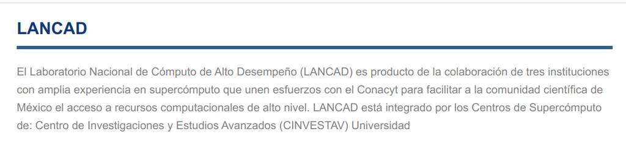

[figure not shown]

## 3.4 Acceso a super cómputo por protocolo SSH

- SSH (Secure Shell) es un programa para entrar en una máquina remota y ejecutar comandos en esa máquina.
- El protocolo SSH proporciona comunicaciones seguras y encriptadas entre dos hosts a través de una red insegura.

*Estructura base:*

```
usuario@sistema:~$ ssh -p puerto usuario@direccionIP
```

*Supercómputo del Laboratorio de Ecología UNAM*

```
usuario@sistema:~$ ssh -p 4020 user4@132.248.49.137
```

## 4. Pasos iniciales con la interfaz de la línea de comandos

#### 4.1 El entorno de la terminal

- El entorno de la terminal: La pantalla de la terminal representa nuestro interprete de comando, así como lo observamos, está listo para empezar a recibir ordenes que posteriormente transformará en en resultados.
- Se llama prompt a los caracteres que se muestran en una línea de comandos para indicar que está a la espera de recibir órdenes.

Al lado izquierdo del cursor (_) se observará siempre  
i. el nombre de usuario  
ii. el nombre de la máquina o sistema  
iii. el lugar en el que nos encontramos (~).

```
usuario@sistema:~$_
```

##### 4.2 Introducción a GitHub

Los proyectos involucrados con Ciencia de Datos incluyen una colección de datos, código fuente/scrips, figuras, informes , etc, los cuáles sufren modificaciones durante el curso del proyecto.

**Git**  
- Sistema de control de versiones, útil para grupos que trabajan proyectos colaborativos involucrados cómo desarrollo de software.  
- Registra la evolución de un archivo a través del tiempo, e identificar los cambios hechos por cada colaborador.  
- Para más información entra a [Happy Git with R](https://happygitwithr.com/).

[figure not shown]

GitHub

**Github:**  
- Host remoto en Internet, que actúa como un canal de distribución para los proyectos administrados por Git.  
- Permite compartir, almacenar y sincronizar proyectos entre los colaboradores de **manera remota**, para realizar lectura y edición de los archivos, a través de los llamados **repositorios**

*Ventajas:*

[figure not shown]

## 4.3 Descargar material del curso con git

En tu sesión del cluster “/home/user1/” copia y pega lo siguiente:

```
usuario@sistema:~$ git clone https://github.com/ConservationGenomicLab/BashECOSUR2025.git
```

#### 4.4 Organización de directorios

El sistema de archivos de GNU/Linux tiene una estructura jerárquica de directorios y subdirectorios que dependen del directorio raíz.  
Se puede imprimir la estructura de directorios de tu home u otro directorio:

[figure not shown]

```bash
tree  -L 2
```

```
## .
## ├── 02.Directorio
## ├── BashECOSUR2025.Rproj
## ├── DataBases
## │   ├── ConteoElementos.csv
## │   ├── Genes.txt
## │   ├── InsectSprays.csv
## │   ├── Mosca_InsectSprays.csv
## │   ├── Pseudomonas.faa
## │   ├── Subset_InsectSprays.csv
## │   └── Tratamientos.txt
## ├── Ejercicios_Bash
## │   ├── documentos
## │   ├── fotos
## │   └── musica
## ├── Figuras
## │   ├── git_01.png
## │   ├── git_02.png
## │   ├── githubLogo.png
## │   ├── imagen_01.png
## │   ├── imagen_02.png
## │   ├── imagen_03.png
## │   ├── imagen_04.png
## │   ├── imagen_05.png
## │   ├── installer.png
## │   ├── LANCAD.png
## │   ├── Mobaxterm1.png
## │   ├── Mobaxterm.png
## │   ├── RECURSUS.png
## │   ├── supercomputo.jpeg
## │   └── ubicaciones.png
## ├── README.md
## ├── Requerimientos.pdf
## ├── Requerimientos.Rmd
## ├── Scripts
## │   ├── AdivinaEdad.sh
## │   ├── AdivinarValores.sh
## │   ├── CaraCruz.sh
## │   ├── Hello.sh
## │   ├── test.sh
## │   └── Variable.sh
## ├── TutorialBash.html
## └── TutorialBash.Rmd
##
## 9 directories, 34 files
```

*Ubicación del directorio actual*  
Para iniciar a dar órdenes al sistema, es esencial cumplir con la sintaxis adecuada para que se entienda lo que queremos decir o hacer.  
Ej. Si nosotros queremos que el sistema nos muestre el contenido del directorio en el que nos encontramos actualmente no podemos poner “muestrame el contenido del directorio”

```
usuario@sistema:~$ muestrame el contenido del directorio
#El interprete de comandos nos va a decir:
muestrame: no se encontró la orden
```

- Por ejemplo para pedirle al sistema que nos indique dónde nos encontramos ubicados usaremos el comando **pwd** y en pantalla nos desplegará la ubicación.

```
usuario@sistema:~$ pwd
/home/usuario
```

Con la opción **man** (de manual, en inglés) o **help** podemos conocer lo que nos ofrece o puede hacer un comando.

```
usuario@sistema:~$ man pwd
usuario@sistema:~$ pwd --help
```

#### 4.5 Aprendiendo a usar comandos

Los comandos algunas veces necesitan parámetros (opciones y/o argumentos) para establecer opciones específicas.  
a. **¿Qué son las opciones:** Indican sobre qué directorio o archivo hay que ejecutar el programa indicado. Se escribe seguido del comando. Generalmente es una letra precedida por un guion.  
b. **¿Qué es un argumento?** Es una indicación sobre qué directorio o archivo hay que ejecutar el programa indicado. Generalmente se pone después del comando y las opciones.

EJEMPLO

*Comando ls*  
* Lista los archivos de un directorio y muestra información acerca de los FICHEROs (del directorio actual por defecto).  
* Sintaxis: ls [OPCIÓN]… [FICHERO]…  
* Podemos acceder a las opciones de un comando con el manual.

```
usuario@sistema:~$ man ls
```

- Nosotros le podemos pedir al comando que nos muestre el contenido de un directorio con/sin los elementos que contiene:

```
usuario@sistema:~$ ls /home/ -l
```

*NOTAS:* * Hay comandos que no requieren argumentos  
* Es importante tener en cuenta que se debe dejar espacio entre cada componente de la orden. * Dado lo anterior podemos asumir que un comando puede esperar ninguno, uno o varios parámetros.  
* La estructura general queda como sigue:

```
comando  opciones  argumentos
```

- *Es importante resaltar que a las opciones siempre las antecede un guion:*
- El orden de los parámetros y las opciones puede ser indistinto.

```
a. usuario@sistema:~$ ls /home/ -l
b. usuario@sistema:~$ ls -l /home/
```

#### 4.6 Resumen

- El intérprete de comandos espera que le indiquemos una línea de órdenes para ejecutar la tarea que le hayamos indicado.
- La sintaxis básica de una orden es **COMANDO [PARÁMETROS] [OPCIONES]** .
- Con el comando le indico qué tiene que hacer, en las opciones cómo debe hacerlo y con los parámetros le indico los elementos donde tendrá que realizar la acción.
- Para diferenciar entre las partes de una línea de órdenes se utilizan los espacios.
- Puedo obtener ayuda de cualquier comando usando **man/ – help** nombre_del_comando.

#### 4.7 Primer quiz

1. ¿Qué comando nos indica el directorio desde el que estamos ejecutando la orden?
1. pwd
2. cd
3. ls
4. dir
2. ¿Todos los comandos necesitan parámetros para funcionar?
1. Sí, siempre
2. No, nunca
3. Algunas veces son imprescindibles otras serán opcionales
3. El orden correcto para ejecutar una orden es:
1. Comando-opciones-parámetros
2. parámetros-comandos-opciones
3. Opciones-parámetros-comando
4. ¿Cómo separa el intérprete las partes de una línea de órdenes?
1. Guión
2. puntos
3. espacios
5. ¿Cómo se usan las opciones de un comando (también llamadas modificadores)?
1. Se pueden usar separados pero también juntarlos con un único guión
2. Siempre se pondrá un guión seguido de varias letras
3. Obligatoriamente de ponen al final de la línea de comandos
6. ¿Cuáles caracteres se deben evitar usar en los nombres de los archivos y por qué?

#### 4.8 Práctica 1

- Ejecutar en la terminal las tareas:
- Mostrar el directorio actual.
- Listar el contenido del directorio actual.
- Listar el contenido del directorio anterior.
- Imprimir pantalla con los resultados de las tareas ejecutadas y enviarla/subirla a la plataforma para evaluación.

## 5. Navegar por el sistema de directorios y/o archivos.

En esta sesión veremos el sistema de directorios, es decir cómo podemos movernos dentro de nuestro sistema de directorios y/o archivos, como crear, modificar, entre otros.

#### 5.1 Ubicación y contenido

- Tenemos que saber entonces que una instrucción siempre se ejecuta desde un lugar, un punto dentro de mi estructura o sistema de directorios.
- Para empezar a movernos dentro de nuestra estructura de directorios tenemos que utilizar un comando que nos ayude a cambiarnos de directorio, este es el comando *cd*.
- El comando *cd* modifica el directorio actual de trabajo del shell.

```bash
#Directorio actual:
pwd
#Moverme al directorio 02.Directorio:
cd  02.Directorio
#Confirmar el nuevo directorio:
pwd
```

```
## /home/anahicanedo/Escritorio/ECOSUR2025/BashECOSUR2025
## /home/anahicanedo/Escritorio/ECOSUR2025/BashECOSUR2025/02.Directorio
```

- El comando *ls* nos permite listar el contenido de un directorio. Tiene varias opciones que podemos conocer con el manual de ls, entre ellas son: ls -l, ls -lh, ls -lr, ls -lt, ls -ltr. ¿Qué hace cada uno de ellos? :

```bash
# man ls
```

Nota: Para desarrollar los siguientes temas, ingresaremos al cluster con el usuario y contraseña correspondientes. Y ubicarnos en la carpeta Ejercicios_Bash.

#### 5.2 Las rutas. Tipos, usos y características

- La ruta es la localización o ubicación de un archivo o directorio.
- En ocasiones podemos tener un archivo con el mismo nombre pero puede estar localizado en diferentes directorios, por lo tanto, la ruta es particular para cada uno.
- Siempre debemos colocar la ruta precisa del archivo para que nuestro interprete de comandos pueda llevar a cabo la acción que le estamos ordenando.

**Sistema de ventanas gráficas vs. Terminal**  
El sistema de ventana de archivos, es el sistema común de carpetas y documentos que vemos en una computadora con sistema operativo Windows o Mac:

[figure not shown]

La terminal tiene una distribución diferente o una representación gráfica distinta.

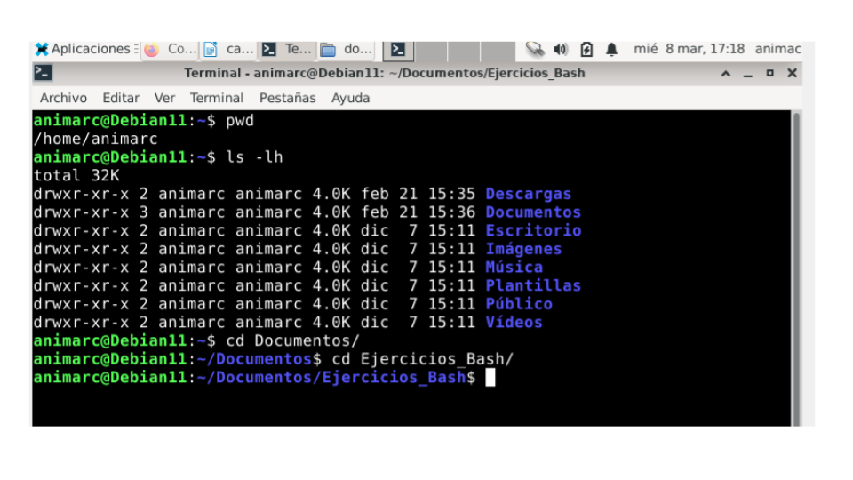

**Rutas absolutas y relativas**  
La ruta absoluta siempre comienza en el directorio raíz (/)

```
    usuario@sistema:~$ cd /home/anahicanedo/Escritorio/ECOSUR2025/BashECOSUR2025/documentos
```

Las rutas relativas indican dónde se encuentra un fichero dentro de un sistema de ficheros comenzando desde el directorio de trabajo o directorio actual

```
     usuario@sistema:~$ cd borradores/primer-trimestre
```

**Sensibilidad entre mayúsculas, minúsculas y espacios**  
El lenguje de Bash es sensible entre mayúsculas, minúsculas y espacios utilizados en los nombres de los ficheros o archivos.

- Por ejemplo para el nombre de un directorio al que le queremos iniciar con una mayúscula:

```
Documentos
```

- Bash reconocerá como un directorio diferente si tenemos otro directorio con el mismo nombre pero inicia con minúscula:

```
documentos
```

- Finalmente si nosotros queremos crear un directorio con un nombre como:

```
mkdir borrador datos finales
```

- Bash creará tres directorio diferentente debido a que va interpretar el espacio como un operador para crear un elemento indipendiente. Lo recomendable en estos casos es utilizar guion medio o guión bajo si deseamos crear directorios o archivos con nombres largos

```
borradores_datos_finales
ó
borradores-datos-finales
```

#### 5.3 Atajos de Bash

Existen tips o atajos en el lenguaje Bash que nos facilita la ejecución de comandos.

| **Atajo** | **Función** |  |
| --- | --- | --- |
| ↑ | Muestra los comandos ejecutados anteriormente |  |
| ../ | Nos posiciona en un directorio anterior |  |
| ↹ | Ayuda a completar/predecir el nombre de un archivo, directorio, rutas, comandos, programas, etc. |  |
| ↹ ↹ | Muestra cuáles elementos podemos elegir dentro del fichero donde estamos posicionados |  |
| > | Sobreescribe un archivo si existe, o crea un nuevo archivo, con el resultado de la salida de un comando |  |
| >> | Agrega el resultado de la salida de un comando, a un archivo ya existete |  |

#### 5.4 Crear, mover, renombrar, copiar y borrar y ver el contenido de archivos y directorios

##### El comando *mkdir*

Función: Permite crear nuevos directorios Sintaxis: mkdir [OPCIÓN]… DIRECTORIO…

```
     usuario@sistema:~$ mkdir ejercicio_1
```

##### El comando *mv*

Función: Permite mover archivos y directorios de un directorio a otro.  
Sintáxis: mv [OPCIÓN]… ORIGEN… DIRECTORIO

```
     usuario@sistema:~$ ejercicio_1 ./borradores
```

Función: También permite renombrar un archivo o directorio.  
Sintáxis: mv Nombre_Inicial …Nombre_Final ..

```
     usuario@sistema:~$ mv ejercicio_1  ejercicios_1
```

##### El comando *rm*

Función: Permite borrar archivos, enlaaces y directorios (sólo sí se incluye opción -r).  
Sintáxis: rm [OPCIÓN]… [FICHERO]…

```
     usuario@sistema:~$ rm -r ejercicios_1
```

##### El comando *cat*

Función1: Permite ver el contenido de archivos  
Sintáxis: cat [OPCIÓN]… [FICHERO]…

```
     usuario@sistema:~$ cat borrador-datos-finales.doc
```

Función2: Permite concatenar archivos  
~~~ usuario@sistema:~$ cat file1 file2 > fileFinal ~~~

##### El comando *cp*

Función: Permite copiar un archivo a otro. También puede copiar varios ficheros en un directorio determinado.  
Sintáxis: cp [OPCIÓN]… ORIGEN… DIRECTORIO  
~~~ usuario@sistema:~$ cp borrador_datos-inicales.doc /home/usuario/Ejercicios_Bash ~~~

#### 5.5 Comodines

- *El asterisco* < * > sirve para indicar que en el lugar donde se encuentra puede haber cualquier cadena de caracteres. Es decir, < *.txt > indica que se incluyen todos los ficheros (directorios y archivos) que tengan cualquier nombre, pero se obliga a que la extensión sea txt.

```
     usuario@sistema:~$ rm /home/alumno/*.txt
```

- *La interrogación* representa cualquier carácter, pero repetido unicamente una vez. El asterisco se podía sustituir por uno o varios caracteres, pero no así la interrogación.

```
     usuario@sistema:~$ rm /home/alumno/borrador-dato?-finales.doc
```

#### 5.6 Editor de texto

- Los editores de texto también se conocen como editores de código.
- Son aplicaciones que permiten generar y editar una gran cantidad de archivos de lenguaje de programación.
- GNU *nano* es un editor de texto de línea de comandos fácil de usar para sistemas operativos Unix y Linux.
- Incluye toda la funcionalidad básica que esperaría de un editor de texto regular.
- Para abrir un archivo existente o para crear un nuevo archivo:

```
usuario@sistema:~$ nano FileName
* Esto abre el archivo o una nueva ventana del editor y se puede comenzar a editar el archivo.
```

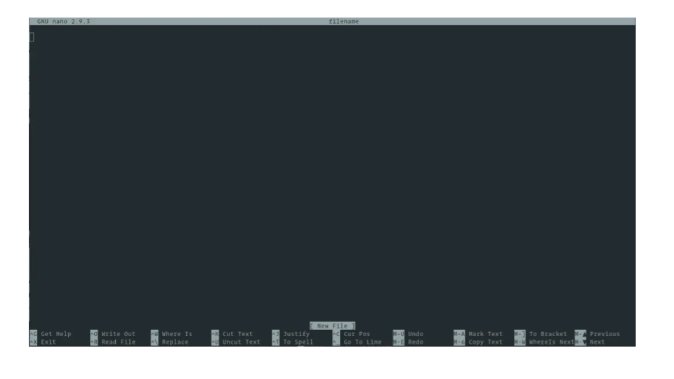

- En la parte inferior de la ventana, hay una lista de los comandos más básicos para usar con el editor.

| *Comando* | *Descripción* |
| --- | --- |
| *Ctrl+G.* | Obtener una lista de todos los comandos |
| *Ctrl+O* | Guardar cambios |
| *Ctrl+X* | Salir del editor |

#### 5.7 Resumen

- El comando pwd muestra el directorio actual
- El comando cd cambia de directorio
- El carácter ~ hace referencia al directorio personal del que ejecuta la orden
- El comando ls despliega una lista con el contenido de un directorio.
- Opciones comunes que modifican cómo se mostrará la información:
  1. -l lista con detalle
  2. -h muestra el tamaño más legible
  3. -a muestra los ocultos
  4. -S ordena por tamaño
  5. -t ordena por fecha
  6. -r invierte el criterio de ordenación
- Para indicar dónde se encuentra un elemento del sistema de ficheros (un archivo o un directorio), utilizo rutas.
- Las rutas pueden ser *absolutas* (indico todos los directorios que tengo que seguir desde la raíz del sistema) o *relativas* (indico el camino desde el directorio donde ejecuto la orden).
- Las rutas absolutas siempre empiezan por una barra / (que indica la raíz)
- Si utilizó **( .. )** en una ruta estoy haciendo referencia al directorio padre.
- Un único punto **( . )** indica el directorio actual
- Linux distingue entre mayúsculas y minúsculas
- Si quiero usar espacio en un nombre deberé ponerlo entre comillas o con un carácter de escape ()
- Usando los cursores arriba y abajo aparecerán las últimas órdenes que he ejecutado
- Puedo ayudarme del tabulador para terminar de escribir una ruta
- Con *Control+R* puedo buscar en el historial de instrucciones
- El comando *history* muestra el historial de instrucciones y puedo ejecutarlas usando el numero_instrucción
- El comando *mkdir* sirve para crear directorios
- El comando *rm* borra ficheros, y con *-r* directorios *(ADVERTENCIA: se debe tener mucho cuidado al utilizar este comando, pues una vez eliminado un fichero o un directorio de esta manera, es IMPOSIBLE recuperarlo)*
- *touch* crea ficheros vacíos
- *mv* mueve elementos o cambia su nombre
- *cat* muestra el contenido de un archivo
- El comando *cp* copia ficheros y directorios
- El símbolo asterisco *(* )* equivale a cualquier secuencia de caracteres en el nombre de un elemento.
- El símbolo interrogación *( ? )* equivale a un sólo carácter, pudiendo éste ser cualquiera.
- Editores de texto en la terminal, existen varios, en este caso trabajamos con nano.

#### 5.8 Segundo quiz

1. ¿Qué hace el comando cd?
1. Muestra el contenido del directorio actual
2. Cambia de directorio
3. Muestra la ruta del directorio actual
2. ¿Qué hace el modificador -l en el comando ls?
1. Muestra los elementos ocultos
2. Muestra los elementos ordenados por fecha
3. Muestra información detallada de cada elemento
3. ¿Qué hace el modificador -S en el comando ls?
1. Muestra el contenido ordenado por tamaño
2. Muestra el contenido ordenado alfabéticamente
3. Muestra el contenido ordenado por la extensión.
4. Si una ruta inicia con (/) podemos afirmar que:
1. Es una ruta absoluta
2. Es una ruta relativa
5. ¿Qué concepto está asociado al uso de ..?
1. El directorio actual
2. El directorio personal del usuario
3. El directorio padre
6. ¿El comando mkdir Fotos crea el directorio fotos?
1. Si
2. No
7. ¿Se pueden utilizar espacios en el nombre de un directorio o archivo?
1. Si, usando comillas
2. No, porque el espacio es un separador entre las partes de la línea de comandos
8. ¿Qué hará el bash si utilizo el tabulador para autocompletar una ruta pero no tiene información suficiente para identificar el elemento de forma exacta?
1. El comando arroja error y se debe volver a escribir
2. Completa la ruta hasta donde sabe, se para y si pulsamos dos veces seguidas nos muestras las posibles opciones
3. Elige la primera de las opciones en orden alfabético
9. ¿Para qué sirve la opción -p del comando mkdir?
1. Para crear un archivo
2. Para crear un directorio varias veces
3. Para crear todos los directorios de la ruta que le indico por parámetro
10. El comando mv sirve para cambiar el nombre de:
1. Archivos/Directorios/Archivos y Directorios
2. rm -r nombre_directorio.
3. Borrará el directorio solo si está vacío
4. No lo borrará porque rm solo borra archivos
5. Borrará el directorio y todo su contenido.
11. El comando cp
1. Puede tener varios elementos de origen
2. Tiene solo un elemento de origen y otro de destino
3. Tiene solo un elemento de destino y varios de origen.
12. ¿Cuál es la funcionalidad básica de un editor de texto?
1. Crear archivos
2. Ejecutar comandos
3. Desarrollar código

#### 5.9 Práctica 2

- Utilizando el directorio Ejercicios_Bash que descargaron a su máquina virtual, utiliza la terminal para realizar los siguientes ejercicios:
1. Copiar el fichero borrador-datos-finales.xls a datos-finales-copia.xls
2. Renombrar pescando.jpg a lubina.jpg
3. Mover estadisticas/ a Ejercicios_Bash/documentos/
4. Borrar todas las canciones de The Corrs
5. Mover todas las fotos en personales/ a un nuevo directorio llamado ficheros/vacaciones/
6. Borrar todo lo que contiene el directorio musica/2009/
7. Mover todos los ficheros con extensión .gif del directorio fotos/ al directorio ficheros/
8. Crea el archivo de texto Practica_2, escribe #este es mi primer archivo de texto. Guardalo dentro de la carpeta Ejercicios_Bash.
9. Como comprobación de la ejecución de todos los ejercicios, teclea el comando history e imprime tu pantalla, adjunta la imagen a tu carpeta de Prácticas.

## 6. Visualización y manipulación de archivos

#### 6.1 Brevario para explorar archivos

A continuación se revisarán algunos comándos básicos utilizados en el sistema de línea de comandos desde el intérprete de bash para poder explorar, visualizar y editar archivos, de forma eficiente.

Sin embargo, antes de revisar los comando, daremos una breve explicación de los principales archivos que estaremos manejando durante el curso y que nos serán útilies para almacenar datos que necesitemos analizar.

#### **Archivos .txt**

Son archivos de texto simple, texto sin formato, o comúnmente conocidos como archivos de texto plano. Contienen únicamente texto formado por caracteres que son legibles por humanos y carece de cualquier tipo de formato tipográfico.

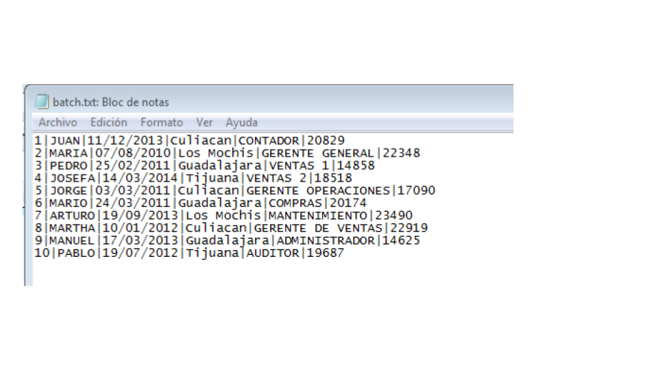

#### **Archivos .csv**

- Los archivos CSV (del inglés “Character-separated values”, Valores Separados por un Delimitador) sirven para almacenar datos tabulares (números y texto) en texto simple.
- Los delimitadores más comunes son la coma (“,”), el punto y coma (“;”) y tabulador (`"\t"`) o espacio (`"\s"`) caracteres invisibles.
- Los archivos separados por coma y por punto y coma, reciben normalmente la extensión **“CSV”**; y los archivos separados por “tab”, la extensión **“TSV”**. Existen también bases de datos en dichos formatos que reciben la extensión **“TXT”**. Los archivos CSV son simples y funcionan con la mayoría de las aplicaciones que trabajan con datos estructurados.

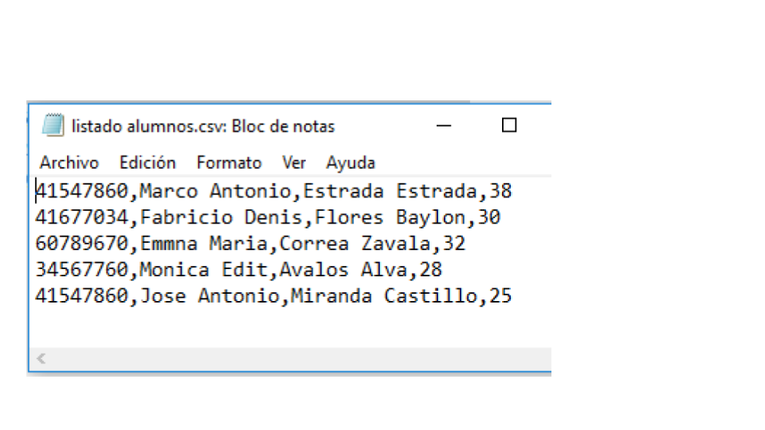

Nota: Para desarrollar los siguientes temas,entrar a la carpeta DataBases para trabajar con el archivo *InsectSprays.csv*.

#### Comando *less*

Función: Despliega archivos página a página  
Sintáxis: *less* FileName

```bash
# less InsectSprays.csv
```

#### Comando *head/tail*

Función: Despliega el encabezado y el final de los archivos (por default muestra 10 líneas)  
Sintáxis: head/tail [OPCIÓN]… [FICHERO]…  
Opciones: head/tail –help  
-n: para indicar el número de líneas que deseas desplegar.

```bash
cd DataBases/
head -n3 InsectSprays.csv
```

```
## Individuo    Tratamiento Tiempo
## Bicho1   Insecticida-Comercial   10
## Bicho2   Insecticida-Comercial   7
```

```bash
cd DataBases/
tail -n3 InsectSprays.csv
```

```
## Bicho48  Matamoscas-Casero   4
## Bicho49  Matamoscas-Casero   3
## Bicho50  Matamoscas-Casero   5
```

- Puedes crear un subset de datos y redireccionar a un nuevo archivo:  
  Sintáxis: head -n(número de líneas) *>* NewFile.csv

```bash
cd DataBases/
head -n15 InsectSprays.csv > Subset_InsectSprays.csv
```

#### Comando *wc*

Función: Imprime conteo de líneas, palabras o caracteres de un archivo  
Sintáxis: *wc* FileName  
Opciones: wc –help  
wc -l Contar el número de líneas de un archivo

```bash
cd DataBases/
wc -l InsectSprays.csv
wc -l Subset_InsectSprays.csv
```

```
## 51 InsectSprays.csv
## 15 Subset_InsectSprays.csv
```

#### Comando *grep*

Función: Se utiliza comunmente para la búsqueda de texto que coincida con los argumentos que le introducimos.  
Puedes buscar archivos en una lista, o dentro de un archivo buscar coincidencias con el texto que introducimos.

Sintáxis: *grep* “string de búsqueda” FileName  
“string_busqueda”= palabra clave a buscar.  
(letra, palabras con espacios, signos de puntuación y caracteres del control)

```bash
cd DataBases/
grep "Insecticida-Comercial" InsectSprays.csv
```

```
## Bicho1   Insecticida-Comercial   10
## Bicho2   Insecticida-Comercial   7
## Bicho3   Insecticida-Comercial   20
## Bicho4   Insecticida-Comercial   14
## Bicho5   Insecticida-Comercial   14
## Bicho6   Insecticida-Comercial   12
## Bicho7   Insecticida-Comercial   10
## Bicho8   Insecticida-Comercial   23
## Bicho9   Insecticida-Comercial   17
## Bicho10  Insecticida-Comercial   20
## Bicho11  Insecticida-Comercial   14
## Bicho12  Insecticida-Comercial   13
```

Opciones: grep –help  
grep -c : imprime solo un número de líneas que coincide con el patrón de búsqueda dentro de un archvio.

**¿Cuántos Bichos tenemos en el archivo InsectSprays.csv?**

```bash
cd DataBases/
# grep -c "Bicho" InsectSprays.csv
```

#### Comando *cut*

Función: Extrae las partes seleccionadas de cada FICHERO en la salida estándar  
Sintáxis: cut [OPCIÓN] … [FileName] …

Opciones:  
cut -d –delimiter: Delimitador de campos. El delimitador por default es un tabulador (`"\t"`); podrías usar espacio (`"\s"`), punto (“.”), guiones (“-”, “_“), comas”,“,etc.

cut -f –fields= Selecciona/muestra solamente los campos de interés

```bash
cd DataBases/
cut  -f 1 InsectSprays.csv
```

```
## Individuo
## Bicho1
## Bicho2
## Bicho3
## Bicho4
## Bicho5
## Bicho6
## Bicho7
## Bicho8
## Bicho9
## Bicho10
## Bicho11
## Bicho12
## Bicho13
## Bicho14
## Bicho15
## Bicho16
## Bicho17
## Bicho18
## Bicho19
## Bicho20
## Bicho21
## Bicho22
## Bicho23
## Bicho24
## Bicho25
## Bicho26
## Bicho27
## Bicho28
## Bicho29
## Bicho30
## Bicho31
## Bicho32
## Bicho33
## Bicho34
## Bicho35
## Bicho36
## Bicho37
## Bicho38
## Bicho39
## Bicho40
## Bicho41
## Bicho42
## Bicho43
## Bicho44
## Bicho45
## Bicho46
## Bicho47
## Bicho48
## Bicho49
## Bicho50
```

#### Comando *sed*

Función:

-Herramienta que permite buscar y reemplazar en un texto.  
-Busca cadenas de texto, palabras o patrones y los reemplaza por el texto que deseas.  
-Permite buscar e insertar/eliminar texto de un documento.  
-Análogo al “buscar y reemplazar” de Microsoft Word

Sintáxis:

```
usuario@sistema:~$ sed 's/texto_a_buscar/texto_a_reemplazar/g' fichero_a_reemplazar > fichero_nuevo
```

```bash
cd DataBases/
sed 's/Bicho/Mosca/g' InsectSprays.csv >  Mosca_InsectSprays.csv
head -n 5 Mosca_InsectSprays.csv
```

```
## Individuo    Tratamiento Tiempo
## Mosca1   Insecticida-Comercial   10
## Mosca2   Insecticida-Comercial   7
## Mosca3   Insecticida-Comercial   20
## Mosca4   Insecticida-Comercial   14
```

**¿Qué sucedió en el archivo Mosca_InsectSprays.csv?**

#### Comando *sort*

Función: Permite ordenar las líneas de un archivo, de manera alfabética, inversa, numericamente, incluso permite eliminar duplicados.  
Sintáxis: sort [OPCIÓN]… [FICHERO]..

Ejemplo:  
* Se desea ordenar de manera alfabética, los tratamientos utilizados para matar bichos en la base de datos InsectSprays.csv:

```bash
cd DataBases/
# cut -f 2 InsectSprays.csv > Tratamientos.txt
# less Tratamientos.txt
# sort Tratamientos.txt
```

**¿Qué ocurre al utilizar el comando y sus diferentes opciones (-d, -r, -u)?**

```bash
cd DataBases/
#sort -d Tratamientos.txt
#sort -r Tratamientos.txt
sort -u Tratamientos.txt
```

```
## Bio-Insecticida
## Insecticida-Comercial
## Lampara-UV
## Matamoscas-Casero
## Tratamiento
```

#### 6.2 Uso del *pipe ’ | ’*

Función: Un pipe es un flujo de datos que circula entre dos procesos. El resultado de un comando o programa, será la entrada para un nuevo comando/programa.  
La ventaja es dividir una tarea grande, en pequeñas tarea o pasos.

Sintáxis:

```
usuario@sistema:~$ Comando-1 | Comando-2 | …| Comando-N
```

Ejemplo:  
* Se desea explorar las primeras líneas del archivo InsectSprays.csv, extraer todas las líneas que contengan la palabra “Bicho”, y cortar la columna 1 para finalmente contabilizar el número de individuos.

```bash
cd DataBases/
head InsectSprays.csv | grep "Bicho" | cut -f 1 | wc -l
```

```
## 9
```

**Mini-Reto: Utilizando los comando cut | grep | wc responde: ¿A cuántos individuos en la base de datos InsectSprays.csv se les aplicó el Bio-Insecticida?**

#### 6.3 Permisos de archivos

| **Atributo** | **Archivos** | **Directorios** |
| --- | --- | --- |
| *r* | abrir y leer | listar contenidos si tiene +x |
| *w* | editar pero no renombrar/borrar (atributo dir) | permite generar archivos en dir, si tiene +x |
| *x* | permite ejecutar archivo (programa) si +r | permite entrar al directorio |

#### 6.4 Cambiar permisos

- Comando *chmod*  
  Función: Sirve para asignar permisos de acceso a carpetas y directorios en sistemas de archivos compatibles con los permisos de archivo típicos de Unix
- Revisar los permisos del archivo

```bash
# ls -l NuevoArchivo.txt
```

```bash
#chmod +w  NuevoArchivo.txt
```

- Asignar permisos de ejecución :

```bash
#chmod +x  NuevoArchivo.txt
```

- Verificar que se hayan realizado los cambios

```bash
# ls -l NuevoArchivo.txt
```

#### 6.5 Resumen

- Imprimir en pantalla la visulización de archivos muy grandes puede causar problemas de memoria RAM, por lo que es aconsejable evitar usar ***less** en estos casos.
- Los comandos head/tail son útiles para explorar el contenido de un archivo.
- El comando *grep* pueden ayudarnos a contar y extraer el número de elementos coincidentes con un patrón de búsqueda.
- Utilizando el símbolo “|” se pueden dar instrucciones seriales para obtener un resultado final de mayor compeljidad.
- El símbolo *“>”* redirecciona la salida de un comando a un archivo, se debe tener cuidado pues, si el archivo ya existe, borrará el contenido anterior; lo mismo sí se usa el comando *sed -e* ; se sobreescribe un nuevo archivo.

#### 6.6 Tercer quiz

En una base de datos (Censo_2020.csv) cuyo tamaño son 5Gb, con 510,000 líneas y 4 columnas. Contiene el número de habitantes por cada municipio en el estado de Tabasco, organizado de la siguiente manera:

| **Municipio** | **No. habitantes** | **Rango de Edad** | **Escolaridad** |
| --- | --- | --- | --- |
| Villahermosa | 100,000 | 20-30 años | Universidad |
| Villahermosa | 100,000 | 20-30 años | Universidad |
| Villahermosa | 100,000 | 20-30 años | Universidad |
| Humanguillo | 300,000 | 50-60 años | Primaria |
| Tenosique | 100,000 | 30-40 años | Secundarias |
| Macuspana | 10,000 | 10-20 años | Preparatoria |

1. Deseas explorar su contenido, ¿qué comando usarías?
1. Utilizas el comando less
2. Utilizas un editor de texto para visualizar la base de datos
3. Tecleas: head -10 Censo_2010.csv
2. Necesitas hacer un subset de los habitantes que pertenecen al municipio de Villahermosa
1. head Villahermosa Censo_2010.csv > Nuevo_Subset
2. grep “Villahermosa” Censo_2010.csv > Nuevo_Subset
3. wc -w Villahermosa Censo_2010.csv > Nuevo_Subset
3. Deseas conocer el número de registros pertenecientes al municipio de Humanguillo:
1. grep -c “Humanguillo” Censo_2010.csv
2. wc -w “Humanguillo” Censo_2010.csv
3. grep “Humanguillo” Censo_2010.csv | wc -l
4. Imagina que quieres distribuir tu código y evitar que otros usuarios puedan realizar cambios, ¿cómo puedes restringir los permisos de edición?
1. Utilizando el comando: chmod -w
2. Escribir un archivo de configuración para el script.
3. Utilizando el comando: chmod -r
5. Descargaste un programa escrito es bash (.sh), y al ejecutarlo te dice: **“Permiso denegado”**…
1. El programa tiene un error al descargarlo
2. No tengo permiso de edición y debo pedir acceso al autor del programa
3. No tengo permiso de ejecución y debo modificar los permisos en la terminal.

#### 6.7 Práctica

#### PARTE 1

*Utiliza pipe “|” para responder las siguientes preguntas acerca del archivo ConteoElementos.csv dentro de la carpeta DataBases. Guarda el historial de tu tarea en un nuevo archivo con el nombre: “Practia3-P1_NombreAlumno.txt*

1. ¿Cuáles son los nombres de las columnas del archivo?
2. ¿Cuántos países contiene la columna #1?
3. ¿Cuántos animales contiene la columna #3?
4. ¿Cuáles y cuántos animales comienzan con la letra “C”? (Pista: Utilizar cut | grep )

#### PARTE 2

**Utiliza el archivo Genes.txt dentro de la carpeta DataBases y guarda el historial en un nuevo archivo “Practica3-P2_NombreAlumno.txt**

1. Muestra las primeras 10 líneas del archivo Genes.txt
2. Identifica ¿Cuál es el string qué se repite?
3. Sustituye NODE por GENE utilizando el comando *sed* y guárdalo en el mismo archivo (Revisa los parámetros del comando que te permitan hacerlo).
4. ¿Cuántos GENES contiene el archivo?

## 7. Transferencia de archivos con protocolo scp

SCP (Secure Copy Protocol) es una herramienta de línea de comandos que permite la transferencia segura de archivos entre sistemas locales y remotos.

Sintáxis: scp [opciones] [archivo] [usuario@servidor:ruta/destino]  
Por ejemplo para descargar del cluster a tu computadora local:

```
usuario@sistema:~$  scp -P 4020  user1@132.248.49.137:/home/user1/BashECOSUR2025/DataBases/Genes.txt  .
```

Para subir archivos de tu computadora local al cluster:

```
usuario@sistema:~$  cd /home/anahicanedo/Escritorio/

usuario@sistema:~$  scp -P 4020 LOCAL_FILE.txt user1@132.248.49.137:/home/user1/BashECOSUR2025/DataBases/
```

#### Tu turno:

**Los instructores del curso te harán llegar por correo electrónico los archivos: “barcodes.txt y bicho_RadSeq.fastq.gz”; deberás subirlos a tu sesión en el cluster en una nueva carpeta que se llame “SecuenciasDNA” para tranajas con ellos las siguientes secciones**

## 8. Archivos de secuenciación masiva, el formato fastq

En esta sección vamos a utilizar los comandos de bash y habilidades que ya hemos visto en el curso.

Los objetivos de esta sección son:

> -**Explorar la estructura de un archivo *fastq* usando comandos básicos.**

> -**Obtener información básica de un archivo *fastq*.**

> -**Extraer las secuencias de un archivo *fastq*.**

> -**Identificar elementos como barcodes o sitios de restricción en las lecturas.**

#### Planteamiento

Usaremos un juego de datos real. Al anlalizar lo datos detectamos una pérdida de información del 22%,cuando normalmente esperamos una pérdida de alrededor del 8% de datos. Usaremos lo aprendido durante el curso para detectar fuentes de error posiblemente asociadas a factores técnicos de la unidad de secuenciación.

En este caso tenemos un fastq generado para 96 muestras de “alguna especie” (más adelante veremos como podemos identificar a que organismo pertenecen) por medio de la técnica de RadSeq con la enzima de restricción *ApeKI*.

Los sitios de corte de la enzima son **GAGC** y **GTGC**.

Los datos constan del archivo *fastq.gz* y del archivo con los índices de cada individuo *barcodes.txt*.

Nota que los datos fueron generados con un submuestreo al azar del archivo original para fines del ejercicio.

#### Parte I

1. **Vamos a identificar los elementos de un archivo fastq.gz.**

> > Usaremos **`zcat`**, que es una variante de **`cat`** que funciona para archivos comprimidos.

> > Usa el pipe **|** junto con **`wc -l`** para conocer cuantas líneas contiene el archivo.

> > Ahora usa **`head`** para observar las primeras líneas del archivo.

> > Usa **`grep -c`** para determinar el número de lecturas. Busca un *“string”* adecuado para este fin.

**Tip:** recuerda usar `ctrl + C` para cortar ó cancelar un proceso.

#### Preguntas:

- ¿Cuántas lecturas tiene el archivo?
- ¿Cuántas líneas componen una lectura fastq?

#### Parte II

1. **Extraer las secuencias nucleotídicas de un archivo fastq**

Vamos a “aislar” las secuencias del formato fastq: **Tip:** Siempre usa una fracción de los datos antes de aplicar tus líneas de comando (*i.e.* usa **`head`** ).

> > Aisla los encabezados de las secuencias con **`grep`**.

> > Utiliza la opción **-A 1** para obtener la línea con las secuencias.

> > Puedes usar **`grep -v`** para eliminar líneas no deseadas. **Tip:** agrega la opición `--no-group-separator`.

> > Almacena tus secuencias en un archivo (usa **>** para direccionar la salida).

#### Preguntas:

- ¿Cuántas secuencias obtuviste?
- ¿Puedes estimar cuántas secuencias tienen bases indeterminadas (*i.e.* **N**’s )?

#### Parte III

1. **Busquemos ahora los barcodes que identifican a los individuos y los sitios de restricción.**

> > Como vimos anteriormente, los barcodes y los sitios de corte se encuentran en las primeras bases nucleotídicas. Vamos a extraer los primeros 15 sitios. Usa **`cut -b`**. No olvides crear un archivo con estas bases nucleotídicas.

> > Revisa el contenido del archivo *barcodes.txt*. Por ahora sólo nos interesa la columna con las secuencias, extrae esta columna con **`cut`** y genera un nuevo archivo.

> > Ahora busquemos las secuencias de los barcodes en nuestro archivo que generamos en el paso anterior. Prueba usando la opción **`-f`** seguido del nombre del archivo.

> > Estima cuántas secuencias tienen alguno de los barcodes.

> > Ahora estima cuántas tienen los sitios de restricción.

#### Preguntas:

- ¿Cuántas secuencias tienen tanto los barcodes como los sitios de restricción?
- ¿Del total de lecturas, qué porcentaje se perdieron por no tener los barcodes o los sitios de restricción?

#### Notas finales:

El *fastq* que trabajamos representa un caso real de errores en la preparación de las bibliotecas por parte de la unidad de secuenciación. Genearlmente este tipo de errores no están asociados a la calidad del tejido o pureza de la extracción.

Estos resultados nos permiten tomar desiciones para decidir por parámetros y estrategias para obtener la mayor cantidad de marcadores.

Considera que en bash hay varias maneras de obtener un resultado, en este caso el ejercicio tiene un objetivo demoastrativo y con ello no suponemos que es la única manera de hacerlo.

En nuestra experiencia siempre recomendamos revisar los archivos “crudos” antes de usar algún programa. Esto nos da señales de la calidad de la secuenciación y posibles problemas asociados.

## 8.2 El poderosísimo awk

*El uso de *awk* para la edición y manipulación de secuencias en formato fasta*

Ahora vamos revisar las aplicaciones de *awk* para editar secuencias fasta.

*awk* es un lenguaje con una sintaxis particular. No es el objetivo de la presente práctica ser un manual o guía de awk, más bien queremos mostrar las apliaciones para resolver problemas comunes cuando trabajamos con secuencias. En particular, *awk* es muy eficiente cuando trabajamos con grandes volúmenes de secuencias.

#### Parte I

Vamos a generar un archivo fasta a partir de las secuencias que obtuvimos en el ejercicio anterior:

Como siempre, empieza con una fracción de los datos. Suponiendo que el archivo con las secuencias que generaste anteriormente se llama *Secuencias.txt* :

```
usuario@sistema:~$ head Secuencias.txt | awk '{print ">seq_" ++count ORS $0}'
```

Observa el comando, identifica que hace cada elemento, y cuando estés conforme genera tu archivo completo en formato fasta.

#### Preguntas

- ¿Cómo pondrías otro nombre al prefijo al nombre de las secuencias?

#### Parte II

El tamaño en número de bases muy importante cuando trabajamos secuencias. Obtengamos un estimado del largo de las secuencias:

```
usuario@sistema:~$ awk '/^>/{if (l!="") print l; print; l=0; next}{l+=length($0)}END{print l}' Secuencias.fasta
```

Vamos un poco más allá y veamos como se distribuyen los tamaños. Para esto vamos a usar **R**. Primero obtén la lista los conteos únicamente, prueba usando **`grep`** ó **`sed`**.

```
usuario@sistema:~$ R
```

Dentro de **R**, vas a observar un mensaje con la versión y promt **>**.

```
#Suponiendo que el archivo con los tamaños se llama seq_sizes.txt vamos a cargar los datos.
seq_sizes <- read.table(file="seq_sizes.txt")
#un resumen estadístico de los valores.
summary(seq_sizes)
#vamos agenerar un gráfico
png("Sizes.png")
hist(seq_sizes$V1,col="red4",border="white",xlab="Tamaño del fragmento")
dev.off()
#listo, ahora salgamos de R
q(save=no)
```

Descargar el archivo “Sizes.png” a tu computadora local para visualizarlo.

#### Preguntas

- **R** es un lenguaje distinto a **bash**, ¿Puédes identificar dos diferencias fundamentales en sus sintaxis?

De regreso en **bash** copia el gráfico a tu computadora.

Vamos a filtrar por tamaño, digamos como mínimo 120pb:

```
usuario@sistema:~$ awk -v RS='>[^\n]+\n' 'length() >= 120 {printf "%s", prt $0} {prt = RT}' Secuencias.fasta
```

#### Preguntas

- Escoge distintos tamaños y observa como cambia el número de secuencias recuperadas.

Podemos ordenar las secuencias por tamaño:

```
usuario@sistema:~$ awk '/^>/ {printf("%s%s\t",(N>0?"\n":""), $0);N++;next;} {printf("%s",$0);} END {printf("\n");}' Secuencias.fasta |\
awk -F '\t' '{printf("%d\t%s\n",length($2),$0)}' |\
sort -k1,1n | cut -f 2- |tr "\t" "\n" > Secuencias_size.fasta
```

#### Parte III

Como lo prometimos en el ejercicio anterior, vamos a tratar de identificar a que organismo pertenecen las secuencias.

Considera que tenemos muchas secuencias. Esto puede causar que la búsqueda sea muy tardada, vamos a escoger las primeras secuencias:

```
usuario@sistema:~$ awk '/^>/ {n++} n>5 {exit} {print}' Secuencias.fasta
```

Si quisiéramos un muestreo al azar podemos usar:

```
usuario@sistema:~$  cat Secuencias.fasta |\
    awk '/^>/ { if(i>0) printf("\n"); i++; printf("%s\t",$0); next;} {printf("%s",$0);} END { printf("\n");}' |\
    shuf |\
    head -n 5 |\
    awk 'BEGIN{FS="\t"}{printf("%s\n%s\n",$1,$2)}'
```

Ok, se ve complicado pero de hecho es muy eficiente.

```
usuario@sistema:~$ blastn -db nt -query Secuencias_mini.fasta -remote -html -out resultados_f.html
```

La búsqueda va a tardar dependiendo de la velocidad de la conexión y la carga de trabajo del NCBI, mientras tanto veamos otras utilidades de **awk**.

Mientras tanto vamos a ver otras funcionalidades de *awk*:

Si quisieramos separar las secuencias en archivos individuales:

```
usuario@sistema:~$ awk '/^>/{s=++d".fa"} {print > s}' Secuencias_mini.fasta
```

O bien juntarlas:

```
usuario@sistema:~$  awk '1' *.fasta > all .fasta
```

Seleccionar solo las secuencias que tengan un nombre o clave específico:

```
usuario@sistema:~$  awk 'BEGIN {RS=">"} /seq/ {print ">"$0}' Secuencias_mini.fasta
```

Vamos a editar los nombres de las secuencias.

```
usuario@sistema:~$ awk -v dato1="Mis_secuencias" -v dato2="nuevas" '/^>/ {gsub(/^>/,">" $2 "|" dato1 "|" dato2 "-" ); printf "%s\n",$0;next} {print}' Secuencias_mini.fasta
```

#### Preguntas

- ¿Cómo le quitarías esos nuevos nombres a tus secuencias?
- Genera tu juego de secuencias, cambia el separador y la información de los nombres.

Los resultados de la búsqueda ya deben de estar listos, revisa el archivo *resultados_f.html* con **`grep`**. Copia el archivo a tu computadora y ábrelo con algún navegador.

#### Preguntas

- ¿Con qué organismo estamos trabajando?
- ¿Cuántas secuencias no tienen homólogía en la base de datos? ¿Por qué crees que pasa esto?
- Es posible que en algunos casos obtengamos especies muy divergentes, ¿Por qué crees que pasa esto?
- Hay un factor clave qye puede estar afectando la búsqueda. ¿Cuál es y como podrías solucionarlo?

## 9.0 cdbtools

cdbtools es una colección de herramientas utilizadas para crear índices para la recuperación rápida de cualquier secuencia particular de archivos multi-FASTA de gran tamaño.

¿Cómo se hace?

1. Crear una nueva carpeta “cdbtools”
2. Copia el archivo Pseudomonas.faa de la carpeta DataBases, a la nueva carpeta que acabas de crear
3. Visualiza el archivo y observa atentamente. ¿Qué tipo de archivo tenemos? ¿Qué información contiene?
4. Escribe en un nuevo archivo el ids de un gen de tú interés. Ej: El locus_00007 pertenece a una L-threonine dehydratase catabolic TdcB

```
usuario@sistema:~$  echo "locus_00007" > idextract
usuario@sistema:~$ less idextract
```

2. Indexar el genoma

```
usuario@sistema:~$  cdbfasta Pseudonomas.faa
```

3. Extraer la secuencia de aminoácidos correspondiente del gen de interes

```
usuario@sistema:~$ cat idextract | cdbyank Pseudomonas.faa.cidx  > Gene_TdcB.fna
```

#### Tu turno:

**En el archivo Pseudomonas.faa hay muchas proteinas que no tienen una identidad y aparecen como “hypothetical protein”. Con los comandos que hemos revisado, extrae unicamente los ids de las proteinas que sí tienen una identidad y enlistalas en un nuevos archivo; después obtén un subset de las secuencias correspondientes a estas proteínas identificadas.**

## 10. Sintaxis del lenguaje para generar scripts

#### 10.1 ¿Por qué usar scrips?

```
* Automatizar procesos, eliminar tareas repetitivas y ahorrar tiempo.
* Planifica el flujo de trabajo. Proporciona una secuencia de actividades bien estructuradas y secuenciales.
* Un script se puede ejecutar cuántas veces quieras, incluso por diferentes usuarios, permite compartir código con una comunidad.
* Con scripts, podemos proporcionar valores dinámicos a comandos usando argumentos de línea de comando
* Los comandos, variables y entornos pueden ser utilizados de manera eficiente y eliminarlos si no se van a requerir nuevamente, hace más eficiente el uso de los recursos.
* Se pueden escribir programas interactivos
```

- Los comentarios son una parte esencial en cualquier pieza de código. Son partes del código que no se ejecutan, inician con el símbolo # (tu yo del presente le recuerda a tu yo del futuro qué querías hacer o para qué sirve cada script; también es fundamental para que cualquier otra persona pueda usar tú script y comprender qué está haciendo)

```
#Esto es un comentario en Bash.
aqui-va-el-codigo
#Este es otro comentario.
```

Al añadir # al iniciar la línea, lo que están haciendo es inhabilitarla para que no pueda ser ejecutada por el interprete de comandos. También se puede utilizar para inhabilitar trozos de código que por el motivo que sea, no se quiere ejecutar en este momento.

#### 10.2 Impresión de texto **echo**

- La impresión de texto es una de las formas iniciales para aprender la sintaxis de cualquier lenguaje de programación, con el famoso «hola mundo».
- Para imprimir una línea de texto en Bash, se utiliza la sentencia **echo** seguida del texto que quieres mostrar por pantalla entre comillas. Por ejemplo:

```bash
echo "Hola mundo"
```

```
## Hola mundo
```

#### 10.3 Variables

- Las variables de entorno se utilizan para almacenar algunos valores que pueden ser utilizados por los comandos
- Existen las variables globales y variables locales. La variable local se ejecuta solo en el shell donde se definió, mientras que la variable global es para cualquier proceso en ejecución o que se ejecute desde el shell.
- Si queremos ver las variables de entorno que estamos usando y que estan cargadas en nuestra sesión, escribe el comando printenv
- No se necesita declarar la variable previamente, ni tampoco indicar el tipo de valor que tendrá. Para crear un variable, tan solo hay que indicar su nombre, el operador igual, y el valor que le quieres asignar. Este puede ser un número, un carácter o un string (cadena de caracteres).

```bash
#Crear una nueva variable en Bash
frase="FRASE: Este es mi primer script en Bash"
echo $frase
#Crear otra variable
edad=25
echo "EDAD: $edad"
```

```
## FRASE: Este es mi primer script en Bash
## EDAD: 25
```

#### 10.4 Estructuras de control y bucles

**Son el conjunto de reglas que permiten controlar el flujo de ejecución de las instrucciones de un algoritmo o de un programa**.

Las estructuras de control se pueden clasificar en:  
- **Secuenciales**: Se refiere a un conjunto de acciones que se ejecutan en un orden específico y se suceden una tras otra.

```
varA=5
varB=95
varC=2
Acción1 --> Acción2 --> Acción3
suma varA+varB ---> "el resultado dividelo entre varC" --> "Imprime el resultado"

Acción1: 5+95=100
Acción2: 100/2=50
Acción3: 50
```

- **Condicionales**: Nos permte plantear una pregunta simple cuya respuesta deberá ser VERDADERO o FALSO, y hacer una acción subsecuente.

```
A=10
B=1
¿El valor de A es mayor que el valor de B?
De ser VERDADERo, guarda el valor de A en una nueva variable.
```

- **Iterativas**: Acciones que se ejecutan repetidamente hasta que se cumpla una condición determinada.

```
"Camina en línea recta hasta topar con pared..."

Escribe un número x, hasta que x sea igual a 100...
1
2
...
100
```

**OPERADORES BOLEANOS EN PROGRAMACIÓN BASH**

**Comparaciones de cadenas alfanuméricas**

| **Operador** | **Verdad (TRUE) si:** |
| --- | --- |
| = | **A** es igual **B** |
| != | **A** no es igual **B** |
| < | **A** es menor que **B** |
| > | **A** es mayor que **B** |

**Comparación de valores numéricos**

| **Operador** | **Verdad (TRUE) si:** |
| --- | --- |
| x -lt y | **x menor que y** |
| x -le y | **x menor o igual que y** |
| x -eq y | **x igual que y** |
| x -ge y | **x mayor o igual que y** |
| x -gt y | **x mayor que y** |
| x -ne y | **x no igual que y** |

#### 10.5 Ciclo if, then, else

- En el caso de las estructuras condicionales la más utilizada es el if .. then .. else.
- La estructura if permite que un programa decida si ejecuta una sentencia o un bloque de sentencias, en caso de que la condición sea verdadera, o bien si salta su ejecución, en caso de que la condición sea falsa.
- El formato general consiste primero en introducir en una línea la sentencia *if* seguida de la condición entre *[corchetes]* y acabando con *“;”*. A continuación se utiliza el *then* en una nueva línea, y debajo va el código que se ejecuta, si se cumple la condición indicada arriba. Se puede incorporar un else (de manera opcional) junto con el código a ejecutar en caso de que no se cumpla la condición. Para cerrar el ciclo, terminaremos con un *fi*.

```
if [condicion];
then
  comandos-codigo
else
  comandos-codigo
fi
```

Ejemplo:

```bash
var1=gato
var2=perro

if [$var1 = $var2]; then
    echo ${var1}  es igual que ${var2}
else
        echo ${var1} no es igual a ${var2}
fi
```

```
## bash: línea 4: [gato: orden no encontrada
## gato no es igual a perro
```

```bash
#Establecer variables numéricas:
A=200
B=100
#Comparaciones entre valores numéricos
if [ $A -gt $B ]; then
    echo "Es cierto que elemento ${A} es mayor a elemento ${B} "
else
        echo "NO es cierto que elemento ${A} es mayor a elemento ${B} "
fi
```

```
## Es cierto que elemento 200 es mayor a elemento 100
```

- De igual modo que ocurre con las estructuras condicionales, las construcciones de iteración son otro gran clásico. En este caso hay dos sentencias diferentes que podemos utilizar. Por un lado tenemos el for .. do, y por otro lado el while .. do. Al finalizar el código de ejecución, se indica la sentencia done en una nueva línea, para cerrar el bucle.

#### 10.6 Ciclo For

```
for elemento in [lista] ;
do
   comandos que pueden utilizar $elemento ;
done
```

```bash
for i in {1..5}; do echo Estudiante $i; done
```

```
## Estudiante 1
## Estudiante 2
## Estudiante 3
## Estudiante 4
## Estudiante 5
```

```bash
for i in {A..E}; do echo Estudiante $i; done
```

```
## Estudiante A
## Estudiante B
## Estudiante C
## Estudiante D
## Estudiante E
```

```bash
frutas="Manzana Pera Uva"

for i in ${frutas}; do
    echo Aquí tenogo una: "$i"
done
```

```
## Aquí tenogo una: Manzana
## Aquí tenogo una: Pera
## Aquí tenogo una: Uva
```

**¿Qué está imprimiendo el comando echo?**

#### 10.6.1 Utilidad de combinar de comando en un ciclo for

```bash
# ls *.sh
```

```bash
cd  /home/anahicanedo/Escritorio/ECOSUR2025/BashECOSUR2025/Scripts
for i in *.sh ; do name=`echo $i | cut -d "." -f 1` ; echo CicloFor_$name ;done
```

```
## CicloFor_AdivinaEdad
## CicloFor_AdivinarValores
## CicloFor_CaraCruz
## CicloFor_Hello
## CicloFor_test
## CicloFor_Variable
```

**¿Qué está guardando la variable “name”?**

```bash
#cat *.sh > Lista
#for i in $(cat Lista); do mv $i Nuevo_$i ; done
```

#### 10.7 Ciclo while

```
while
  condicion
do
  comandos
done
```

```bash
VAR=0

while [ $VAR -le 10 ]; do
    echo "\$VAR: $VAR"
    let VAR=$VAR+1
done
```

```
## $VAR: 0
## $VAR: 1
## $VAR: 2
## $VAR: 3
## $VAR: 4
## $VAR: 5
## $VAR: 6
## $VAR: 7
## $VAR: 8
## $VAR: 9
## $VAR: 10
```

```bash
contador=1
termina=10
while [ $termina -ge $contador ]
do
  echo Participante No. $contador
  let contador=$contador+1
done
```

```
## Participante No. 1
## Participante No. 2
## Participante No. 3
## Participante No. 4
## Participante No. 5
## Participante No. 6
## Participante No. 7
## Participante No. 8
## Participante No. 9
## Participante No. 10
```

**Mini-reto: Enlista 1000 jugadores usando un ciclo, y re direccona la salida a un nuevo archivo. while**

#### 10.8 Crear y ejecutar scripts

1. Crear un archivo File.sh con el editor de texto nano

```
usuario@sistema:~$ nano MiPrimerScript.sh
```

2. Modifica el archivo escribiendo en la primera línea el siguiente comando:

```
#!/bin/bash
```

3. Cambiar los permisos de ejecución:

```
usuario@sistema:~$ chmod +x MiPrimerScript.sh
```

4. Ejecuta el script

```
usuario@sistema:~$ bash MiPrimerScript.sh
```

```
usuario@sistema:~$ ./MiPrimerScript.sh
```

#### 10.9 Scripts interactivos

El comando *read* lee su entrada estándar y asigna las palabras leídas en la(s) variable(s) cuyo nombre se pasa como argumento. Por ejemplo, para indicar que debemos detener la ejecución para leer un determinado texto que introduzca el usuario, lo más común es utilizar la sentencia *read*, seguido del nombre de la *variable* en la cual quieres que se almacene el texto leído.

**Ve a tu terminal, y crea un nuevo script:**

```
#!/bin/bash
usuario=$1
echo  Introduce tu usuario
read usuario
echo Bienvenido, $usuario
```

```
#!/bin/bash
echo "Adivina mi edad:"
read edad
if [ $edad -eq 30 ]; then
  echo "¡Correcto!"
  exit 0
else
  echo "¡Incorrecto!"
exit 1
fi
```

**Mini-reto: Modifica el último script, a manera que el script pregunte por los kilómetros recorridos por un automóvil 2010; y si el usuario escribe un número entre el rango de 90,000 a 130,000 km; será correcto**

#### 10.10 Resumen

- El símbolo # es para especificar comentarios dentro de los scripts.
- Para imprimir una línea de texto en Bash, se utiliza la sentencia echo seguida del texto entre comillas.
- El comando read es utilizado por el usuario cuando se desea introducir texto en un proceso que se está ejecutando.
- Las variables de entorno pueden ser globales, que se ejecutan para cualquier proceso, y locales que se ejecutan donde fueron definidas.  
  *Las estructuras condicionales if, then, else se utilizan para indicar si se va a realizar una u otra acción en función de una pregunta.*  
  Los Bucles for .. do, while .. do son utilizados para realizar tareas repetitivas.